# 1 Accessing Text Corpora

# 2. Conditional Frequency Distributions

We saw that given some list `mylist` of words or other items, `FreqDist(mylist)` would compute the number of occurrences of each item in the list.

A **conditional frequency distribution** is a collection of frequency distributions, each one for a different "condition".

The condition will often be the category of the text.

## 2.1 Conditions and Events

A **frequency distribution** counts observable events, such as the appearance of words in a text.

A conditional frequency distribution needs to **pair each event with a condition**. So instead of processing a sequence of words, we have to process **a sequence of pairs**.

```python
text = ['The', 'Fulton', 'County', 'Grand', 'Jury', 'said']
```

```python
pairs = [('news', 'The'), ('news', 'Fulton'), ('news', 'County')]
```

Each pair has the form `(condition, event)`. If we were processing the entire Brown Corpus by genre there would be 15 conditions (one per genre), and 1,161,192 events (one per word).

## 2.2 Counting Words by Genre

Whereas `FreqDist()` takes a simple list as input;

`ConditionalFreqDist()` takes a list of pairs.

```python
from nltk.corpus import brown
```

```python
cfd = nltk.ConditionalFreqDist(
    (genre, word)
    for genre in brown.categories()
    for word in brown.words(categories=genre))
```

```python
# recall the list comprehensions
genre_word = [(genre, word)
              for genre in ['news', 'romance']
              for word in brown.words(categories=genre)]
```

```python
len(genre_word)
```

```
170576
```

```python
genre_word[:10]
```

```
[('news', 'The'),
 ('news', 'Fulton'),
 ('news', 'County'),
 ('news', 'Grand'),
 ('news', 'Jury'),
 ('news', 'said'),
 ('news', 'Friday'),
 ('news', 'an'),
 ('news', 'investigation'),
 ('news', 'of')]
```

```python
genre_word[-10:]
```

```
[('romance', 'Washington'),
 ('romance', 'episode'),
 ('romance', "''"),
 ('romance', '.'),
 ('romance', '``'),
 ('romance', "I'm"),
 ('romance', 'afraid'),
 ('romance', 'not'),
 ('romance', "''"),
 ('romance', '.')]
```

We can now use this list of pairs to create a `ConditionalFreqDist`, and save it in a variable `cfd`.

```python
import nltk
```

```python
cfd = nltk.ConditionalFreqDist(genre_word)
```

```python
cfd
```

```
<ConditionalFreqDist with 2 conditions>
```

```python
cfd.conditions()
```

```
['news', 'romance']
```

Let's access the two conditions, and satisfy ourselves that **each is just a frequency distribution**:

```python
print(cfd['news'])
```

```
<FreqDist with 14394 samples and 100554 outcomes>
```

```python
print(cfd['romance'])
```

```
<FreqDist with 8452 samples and 70022 outcomes>
```

```python
cfd['romance'].most_common(20)
```

```
[(',', 3899),
 ('.', 3736),
 ('the', 2758),
 ('and', 1776),
 ('to', 1502),
 ('a', 1335),
 ('of', 1186),
 ('``', 1045),
 ("''", 1044),
 ('was', 993),
 ('I', 951),
 ('in', 875),
 ('he', 702),
 ('had', 692),
 ('?', 690),
 ('her', 651),
 ('that', 583),
 ('it', 573),
 ('his', 559),
 ('she', 496)]
```

```python
cfd['romance']['could']
```

```
193
```

## 2.3 Plotting and Tabulating Distributions

A `ConditionalFreqDist` provides some useful methods for **tabulation and plotting**.

Try to understand the following codes:

```python
from nltk.corpus import inaugural
```

```python
inaugural_cfd = nltk.ConditionalFreqDist(
    (target, fileid[:4])
    for fileid in inaugural.fileids()
    for w in inaugural.words(fileid)
    for target in ['america', 'citizen']
    if w.lower().startswith(target))
```

```python
inaugural_list = [(target, fileid[:4])
    for fileid in inaugural.fileids()
    for w in inaugural.words(fileid)
    for target in ['america', 'citizen']
    if w.lower().startswith(target)]
```

```python
inaugural_list[:10]
```

```
[('citizen', '1789'),
 ('citizen', '1789'),
 ('citizen', '1789'),
 ('citizen', '1789'),
 ('citizen', '1789'),
 ('america', '1789'),
 ('america', '1789'),
 ('citizen', '1793'),
 ('america', '1793'),
 ('america', '1797')]
```

```python
inaugural_list[-10:]
```

```
[('america', '2021'),
 ('america', '2021'),
 ('america', '2021'),
 ('america', '2021'),
 ('america', '2021'),
 ('america', '2021'),
 ('america', '2021'),
 ('america', '2021'),
 ('america', '2021'),
 ('america', '2021')]
```

```python
from nltk.corpus import udhr
```

```python
languages = ['Chickasaw', 'English', 'German_Deutsch','Greenlandic_Inuktikut', 'Hungarian_Magyar', 'Ibibio_Efik']
```

```python
cfd = nltk.ConditionalFreqDist(
    (lang, len(word))
    for lang in languages
    for word in udhr.words(lang + '-Latin1'))
```

In the `plot()` and `tabulate()` methods, we can optionally specify which conditions to display with a `conditions= parameter`.

Similarly, we can limit the samples to display with a `samples= parameter`.

It also gives us full control over the order of conditions and samples in any displays.

```python
cfd.tabulate(conditions=['English', 'German_Deutsch'],samples=range(10), cumulative=True)
```

```
                  0    1    2    3    4    5    6    7    8    9
       English    0  185  525  883  997 1166 1283 1440 1558 1638
German_Deutsch    0  171  263  614  717  894 1013 1110 1213 1275
```

We interpret the last cell on the top row to mean that 1,638 words of the English text have 9 or fewer letters.

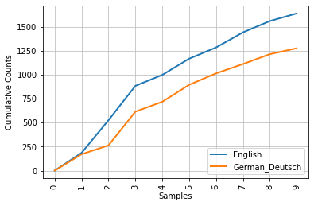

```python
cfd.plot(conditions=['English', 'German_Deutsch'],samples=range(10), cumulative=True)
```

**Exercise**

Working with the *news* and *romance* genres from the Brown Corpus, find out which days of the week are most newsworthy, and which are most romantic.

- Define a variable called `days` containing a list of days of the week, i.e. `['Monday', ...]`.
- Now tabulate the counts for these words using cfd.tabulate(samples=days).
- Now try the same thing using plot in place of tabulate. You may control the output order of days with the help of an extra parameter: `samples=['Monday', ...]`.

## 2.4 Generating Random Text with Bigrams

We can use a **conditional frequency distribution** to create a table of bigrams (word pairs). The `bigrams()` function takes a list of words and builds a list of consecutive word pairs. In order to see the result and not a cryptic "generator object", we need to use the `list()`function:

```python
sent = ['In', 'the', 'beginning', 'God', 'created', 'the', 'heaven','and', 'the', 'earth', '.']
```

```python
list(nltk.bigrams(sent))
```

```
[('In', 'the'),
 ('the', 'beginning'),
 ('beginning', 'God'),
 ('God', 'created'),
 ('created', 'the'),
 ('the', 'heaven'),
 ('heaven', 'and'),
 ('and', 'the'),
 ('the', 'earth'),
 ('earth', '.')]
```

**Example**

Generating Random Text

This program obtains all bigrams from the text of the book of Genesis, then constructs a conditional frequency distribution to record which words are most likely to follow a given word; e.g., after the word *living*, the most likely word is *creature*; the `generate_model()` function uses this data, and a `seed word`, to generate random text.

```python
text = nltk.corpus.genesis.words('english-kjv.txt')
```

```python
type(text)
```

```
nltk.corpus.reader.util.StreamBackedCorpusView
```

```python
text[:10]
```

```
['In',
 'the',
 'beginning',
 'God',
 'created',
 'the',
 'heaven',
 'and',
 'the',
 'earth']
```

```python
bigrams = nltk.bigrams(text)
```

**Note**: 函数`ConditionalFreqDist`接收的参数为`[(condition, event), (condition, event), ...]`，它对`event`进行计数

```python
cfd = nltk.ConditionalFreqDist(bigrams)
```

```python
cfd['living']
```

```
FreqDist({'creature': 7, 'thing': 4, 'substance': 2, 'soul': 1, '.': 1, ',': 1})
```

```python
def generate_model(cfdist, word, num=15):
    for i in range(num):
        print(word, end=' ')
        word = cfdist[word].max()
```

```python
generate_model(cfd, 'living')
```

```
living creature that he said , and the land of the land of the land
```

**Think**: 上述生成过程会陷入死循环，为什么？

Conditional frequency distributions are **a useful data structure for many NLP tasks**. Their commonly-used methods are summarized as follow:

| Example | Description |
| --- | --- |
| `cfdist = ConditionalFreqDist(pairs)` | create a conditional frequency distribution from a list of pairs |
| `cfdist.conditions()` | the conditions |
| `cfdist[condition]` | the frequency distribution for this condition |
| `cfdist[condition][sample]` | frequency for the given sample for this condition |
| `cfdist.tabulate()` | tabulate the conditional frequency distribution |
| `cfdist.tabulate(samples, conditions)` | tabulation limited to the specified samples and conditions |
| `cfdist.plot()` | graphical plot of the conditional frequency distribution |
| `cfdist.plot(samples, conditions)` | graphical plot limited to the specified samples and conditions |
| `cfdist1 < cfdist2` | test if samples in `cfdist1` occur less frequently than in `cfdist2` |

# 3. More Python: Reusing Code

## 3.1 Creating Programs with a Text Editor

## 3.2 Functions

**Example**

Compute lexical diversity for text corpus:

```python
def lexical_diversity(my_text_data):
    word_count = len(my_text_data)
    vocab_size = len(set(my_text_data))
    diversity_score = vocab_size / word_count
    return diversity_score
```

```python
from nltk.corpus import genesis
```

```python
kjv = genesis.words('english-kjv.txt')
```

```python
lexical_diversity(kjv)
```

```
0.06230453042623537
```

**Example**

A Python Function: this function tries to work out the plural form of any English noun.

```python
def plural(word):
    if word.endswith('y'):
        return word[:-1] + 'ies'
    elif word[-1] in 'sx' or word[-2:] in ['sh', 'ch']:
        return word + 'es'
    elif word.endswith('an'):
        return word[:-2] + 'en'
    else:
        return word + 's'
```

```python
plural('fairy')
```

```
'fairies'
```

```python
plural('woman')
```

```
'women'
```

## 3.3 Modules

A collection of variable and function definitions in a file is called a Python **module**.

A collection of related modules is called a **package**.

**Examples**

- NLTK's code for processing the Brown Corpus is an example of a module.
- Its collection of code for processing all the different corpora is an example of a package.
- NLTK itself is a set of packages, sometimes called a **library**.

# 4. Lexical Resources

**A lexicon, or lexical resource**, is **a collection of words and/or phrases** along with associated information such as **part of speech and sense definitions**.

Lexical resources are secondary to texts, and are usually created and enriched with the help of texts.

A **lexical entry** consists of a **headword** (also known as a **lemma**) along with additional information such as the part of speech and the sense definition. Two distinct words having the same spelling are called **homonyms**.

[figure not shown]

**lexical entry examples**

The simplest kind of lexicon is nothing more than a sorted list of words.

Sophisticated lexicons include complex structure within and across the individual entries.

In this section we'll look at some lexical resources included with NLTK.

## 4.1 Wordlist Corpora

NLTK includes some corpora that are **nothing more than wordlists**.

The Words Corpus is the /usr/share/dict/words file from Unix, used by some spell checkers.

We can use it to **find unusual or mis-spelt words** in a text corpus.

**Example**:

Define a function to find the uncommon or mis-spelt words in a text.

```python
# nltk.download('words')
```

```python
def unusual_words(text):
    text_vocab = set(w.lower() for w in text if w.isalpha())
    english_vocab = set(w.lower() for w in nltk.corpus.words.words())
    unusual = text_vocab - english_vocab
    return sorted(unusual)
```

```python
unusual_words(nltk.corpus.gutenberg.words('austen-sense.txt'))
```

```
['abbeyland',
 'abhorred',
 'abilities',
 'abounded',
 'abridgement',
 'abused',
 'abuses',
 'accents',
 'accepting',
 'accommodations',
 'accompanied',
 'accounted',
 'accounts',
 'accustomary',
 'aches',
 'acknowledging',
 'acknowledgment',
 'acknowledgments',
 'acquaintances',
 'acquiesced',
 'acquitted',
 'acquitting',
 'acted',
 'actions',
 'adapted',
 'adding',
 'additions',
 'addressed',
 'addresses',
 'addressing',
 'adhering',
 'adieus',
 'adjusting',
 'administering',
 'admirers',
 'admires',
 'admitting',
 'adorned',
 'advances',
 'advantages',
```

[output cut: 946 more lines]

```
 'oldest',
 'olives',
 'omitted',
 'ones',
 'opened',
 'opinions',
 'opportunities',
 'ordained',
 'orders',
 'originated',
 'ornamented',
 'ornaments',
 'others',
 'outdone',
 ...]
```

```python
unusual_words(nltk.corpus.nps_chat.words())
```

```
['aaaaaaaaaaaaaaaaa',
 'aaahhhh',
 'abortions',
 'abou',
 'abourted',
 'abs',
 'ack',
 'acros',
 'actualy',
 'adams',
 'adds',
 'adduser',
 'adjusts',
 'adoted',
 'adreniline',
 'ads',
 'adults',
 'afe',
 'affairs',
 'affari',
 'affects',
 'afk',
 'agaibn',
 'ages',
 'aggravated',
 'agurlwithbigguns',
 'ahah',
 'ahahah',
 'ahahh',
 'ahahha',
 'ahh',
 'ahhah',
 'ahhahahaha',
 'ahhh',
 'ahhhh',
 'ahhhhhh',
 'ahhhhhhhhhhhhhh',
 'aiiiiiiiiiiiiiiiiiiiiiiii',
 'aiken',
 'aime',
```

[output cut: 946 more lines]

```
 'joined',
 'jokes',
 'joking',
 'jonesboro',
 'jordison',
 'joshy',
 'jr',
 'jrz',
 'jto',
 'jucilicious',
 'judges',
 'jujubees',
 'jumpin',
 'jumps',
 ...]
```

There is also a corpus of **stopwords**, that is, high-frequency words like *the*, *to* and *also* that we sometimes want to filter out of a document before further processing.

Stopwords usually **have little lexical content**, and their presence in a text fails to distinguish it from other texts.

```python
from nltk.corpus import stopwords
```

```python
stopwords.words('english')
```

```
['i',
 'me',
 'my',
 'myself',
 'we',
 'our',
 'ours',
 'ourselves',
 'you',
 "you're",
 "you've",
 "you'll",
 "you'd",
 'your',
 'yours',
 'yourself',
 'yourselves',
 'he',
 'him',
 'his',
 'himself',
 'she',
 "she's",
 'her',
 'hers',
 'herself',
 'it',
 "it's",
 'its',
 'itself',
 'they',
 'them',
 'their',
 'theirs',
 'themselves',
 'what',
 'which',
 'who',
 'whom',
 'this',
```

[output cut: 124 more lines]

```
 "mustn't",
 'needn',
 "needn't",
 'shan',
 "shan't",
 'shouldn',
 "shouldn't",
 'wasn',
 "wasn't",
 'weren',
 "weren't",
 'won',
 "won't",
 'wouldn',
 "wouldn't"]
```

**Example**:

Define a function to compute what fraction of words in a text are not in the stopwords list.

```python
def content_fraction(text):
    stopwords = nltk.corpus.stopwords.words('english')
    content = [w for w in text if w.lower() not in stopwords]
    return len(content) / len(text)
```

```python
content_fraction(nltk.corpus.reuters.words())
```

```
0.735240435097661
```

**Example**:

Use the corpus `nltk.corpus.words` to help solve **Word Puzzle** defined as follow:

[figure not shown]

Word Puzzle

```python
puzzle_letters = nltk.FreqDist('egivrvonl')
```

```python
obligatory = 'r'
```

```python
wordlist = nltk.corpus.words.words()
```

```python
[w for w in wordlist if len(w) >= 4
 and obligatory in w
 and nltk.FreqDist(w) <= puzzle_letters]
```

```
['enrol',
 'ergon',
 'genro',
 'girl',
 'girn',
 'giro',
 'giver',
 'glor',
 'glore',
 'glover',
 'goer',
 'goner',
 'gore',
 'gorlin',
 'govern',
 'grein',
 'grin',
 'groin',
 'grove',
 'grovel',
 'ignore',
 'inro',
 'involver',
 'iron',
 'irone',
 'levir',
 'lienor',
 'lier',
 'liner',
 'linger',
 'lire',
 'liver',
 'livor',
 'livre',
 'loir',
 'longer',
 'lore',
 'lori',
 'lorn',
 'lover',
```

[output cut: 37 more lines]

```
 'veri',
 'vier',
 'vigor',
 'viner',
 'violer',
 'vire',
 'vireo',
 'virl',
 'virole',
 'viron',
 'viver',
 'girl',
 'iron',
 'over',
 'ring']
```

**Example**:

Find those first names that are in both male and female names.

```python
names = nltk.corpus.names
```

```python
# nltk.download('names')
```

```python
names.fileids()
```

```
['female.txt', 'male.txt']
```

```python
male_names = names.words('male.txt')
```

```python
female_names = names.words('female.txt')
```

```python
[w for w in male_names if w in female_names]
```

```
['Abbey',
 'Abbie',
 'Abby',
 'Addie',
 'Adrian',
 'Adrien',
 'Ajay',
 'Alex',
 'Alexis',
 'Alfie',
 'Ali',
 'Alix',
 'Allie',
 'Allyn',
 'Andie',
 'Andrea',
 'Andy',
 'Angel',
 'Angie',
 'Ariel',
 'Ashley',
 'Aubrey',
 'Augustine',
 'Austin',
 'Averil',
 'Barrie',
 'Barry',
 'Beau',
 'Bennie',
 'Benny',
 'Bernie',
 'Bert',
 'Bertie',
 'Bill',
 'Billie',
 'Billy',
 'Blair',
 'Blake',
 'Bo',
 'Bobbie',
```

[output cut: 310 more lines]

```
 'Van',
 'Vin',
 'Vinnie',
 'Vinny',
 'Virgie',
 'Wallie',
 'Wallis',
 'Wally',
 'Whitney',
 'Willi',
 'Willie',
 'Willy',
 'Winnie',
 'Winny',
 'Wynn']
```

**Example**:

Illustrate the relation between the last letter of names and gender with `nltk.ConditionalFreqDist`.

```python
cfd = nltk.ConditionalFreqDist(
    (fileid[:-4], name[-1])
    for fileid in names.fileids()
    for name in names.words(fileid))
```

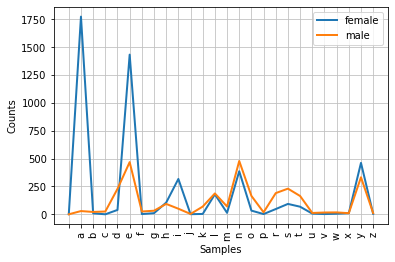

```python
cfd.plot()
```

It can be seen that names ending in the letter **a** and **e** are most female.

## 4.2 A Pronouncing Dictionary

NLTK includes the CMU Pronouncing Dictionary for US English, which was designed for use by **speech synthesizers**.

Learn about this corpus by yourself if you are interested in it.

## 4.3 Comparative Wordlists

NLTK includes so-called Swadesh wordlists, lists of about **200 common words in several languages**. The languages are identified using an ISO 639 two-letter code.

Let's take a brief look at this lexical corpus with the following code snippets.

```python
from nltk.corpus import swadesh
```

```python
# nltk.download('swadesh')
```

```python
swadesh.fileids()
```

```
['be',
 'bg',
 'bs',
 'ca',
 'cs',
 'cu',
 'de',
 'en',
 'es',
 'fr',
 'hr',
 'it',
 'la',
 'mk',
 'nl',
 'pl',
 'pt',
 'ro',
 'ru',
 'sk',
 'sl',
 'sr',
 'sw',
 'uk']
```

```python
swadesh.words('en')
```

```
['I',
 'you (singular), thou',
 'he',
 'we',
 'you (plural)',
 'they',
 'this',
 'that',
 'here',
 'there',
 'who',
 'what',
 'where',
 'when',
 'how',
 'not',
 'all',
 'many',
 'some',
 'few',
 'other',
 'one',
 'two',
 'three',
 'four',
 'five',
 'big',
 'long',
 'wide',
 'thick',
 'heavy',
 'small',
 'short',
 'narrow',
 'thin',
 'woman',
 'man (adult male)',
 'man (human being)',
 'child',
 'wife',
```

[output cut: 152 more lines]

```
 'smooth',
 'wet',
 'dry',
 'correct',
 'near',
 'far',
 'right',
 'left',
 'at',
 'in',
 'with',
 'and',
 'if',
 'because',
 'name']
```

```python
fr2en = swadesh.entries(['fr', 'en'])
```

```python
fr2en
```

```
[('je', 'I'),
 ('tu, vous', 'you (singular), thou'),
 ('il', 'he'),
 ('nous', 'we'),
 ('vous', 'you (plural)'),
 ('ils, elles', 'they'),
 ('ceci', 'this'),
 ('cela', 'that'),
 ('ici', 'here'),
 ('là', 'there'),
 ('qui', 'who'),
 ('quoi', 'what'),
 ('où', 'where'),
 ('quand', 'when'),
 ('comment', 'how'),
 ('ne...pas', 'not'),
 ('tout', 'all'),
 ('plusieurs', 'many'),
 ('quelques', 'some'),
 ('peu', 'few'),
 ('autre', 'other'),
 ('un', 'one'),
 ('deux', 'two'),
 ('trois', 'three'),
 ('quatre', 'four'),
 ('cinq', 'five'),
 ('grand', 'big'),
 ('long', 'long'),
 ('large', 'wide'),
 ('épais', 'thick'),
 ('lourd', 'heavy'),
 ('petit', 'small'),
 ('court', 'short'),
 ('étroit', 'narrow'),
 ('mince', 'thin'),
 ('femme', 'woman'),
 ('homme', 'man (adult male)'),
 ('homme', 'man (human being)'),
 ('enfant', 'child'),
 ('femme, épouse', 'wife'),
```

[output cut: 152 more lines]

```
 ('lisse', 'smooth'),
 ('mouillé', 'wet'),
 ('sec', 'dry'),
 ('juste, correct', 'correct'),
 ('proche', 'near'),
 ('loin', 'far'),
 ('à droite', 'right'),
 ('à gauche', 'left'),
 ('à', 'at'),
 ('dans', 'in'),
 ('avec', 'with'),
 ('et', 'and'),
 ('si', 'if'),
 ('parce que', 'because'),
 ('nom', 'name')]
```

```python
translate = dict(fr2en)
```

```python
translate['chien']
```

```
'dog'
```

```python
translate['jeter']
```

```
'throw'
```

```python
de2en = swadesh.entries(['de', 'en']) # German-English
```

```python
es2en = swadesh.entries(['es', 'en']) # Spanish-English
```

```python
translate.update(dict(de2en))
```

```python
translate.update(dict(es2en))
```

```python
translate['Hund']
```

```
'dog'
```

```python
translate['perro']
```

```
'dog'
```

```python
# compare words in various Germanic and Romance languages
languages = ['en', 'de', 'nl', 'es', 'fr', 'pt', 'la']
for i in [139, 140, 141, 142]:
    print(swadesh.entries(languages)[i])
```

```
('say', 'sagen', 'zeggen', 'decir', 'dire', 'dizer', 'dicere')
('sing', 'singen', 'zingen', 'cantar', 'chanter', 'cantar', 'canere')
('play', 'spielen', 'spelen', 'jugar', 'jouer', 'jogar, brincar', 'ludere')
('float', 'schweben', 'zweven', 'flotar', 'flotter', 'flutuar, boiar', 'fluctuare')
```

## 4.4 Shoebox and Toolbox Lexicons

Perhaps the single most popular tool used by linguists for managing data is *Toolbox*, which is freely downloadable from https://software.sil.org/toolbox/.

# 5. WordNet

**WordNet** is a semantically-oriented dictionary of English, similar to a traditional thesaurus but with a richer structure.

NLTK includes the English WordNet, with 155,287 words and 117,659 **synonym sets**. We'll begin by looking at synonyms and how they are accessed in WordNet.

## 5.1 Senses and Synonyms

Consider the sentence in (a). If we replace the word *motorcar* in (a) by *automobile*, to get (b), the meaning of the sentence stays pretty much the same:

- (a) Benz is credited with the invention of the **motorcar**.
- (b) Benz is credited with the invention of the **automobile**.

Since everything else in the sentence has remained unchanged, we can conclude that the words *motorcar* and *automobile* have the same meaning, i.e. they are **synonyms**.

**Examples**

Explore the structure of WordNet with NLTK as follow:

```python
from nltk.corpus import wordnet as wn
```

```python
wn.synsets('motorcar')
```

```
[Synset('car.n.01')]
```

*motorcar* has just one possible meaning and it is identified as `car.n.01`, the first noun sense of car. The entity `car.n.01` is called a synset, or "synonym set", **a collection of synonymous words (or "lemmas")**.

```python
wn.synset('car.n.01').lemma_names()
```

```
['car', 'auto', 'automobile', 'machine', 'motorcar']
```

**Each word of a synset can have several meanings**, e.g., car can also signify a train carriage, a gondola, or an elevator car (火车车厢、缆车或电梯车厢). However, we are only interested in **the single meaning that is common to all words of the above synset**.

Synsets also come with a **tprose definition and some example sentences**:

```python
wn.synset('car.n.01').definition()
```

```
'a motor vehicle with four wheels; usually propelled by an internal combustion engine'
```

```python
wn.synset('car.n.01').examples()
```

```
['he needs a car to get to work']
```

```python
# get all the lemmas for a given synset
wn.synset('car.n.01').lemmas()
```

```
[Lemma('car.n.01.car'),
 Lemma('car.n.01.auto'),
 Lemma('car.n.01.automobile'),
 Lemma('car.n.01.machine'),
 Lemma('car.n.01.motorcar')]
```

```python
# look up a particular lemma
wn.lemma('car.n.01.automobile')
```

```
Lemma('car.n.01.automobile')
```

```python
# get the synset corresponding to a lemma
wn.lemma('car.n.01.automobile').synset()
```

```
Synset('car.n.01')
```

```python
# get the "name" of a lemma
wn.lemma('car.n.01.automobile').name()
```

```
'automobile'
```

Unlike the word *motorcar*, which is unambiguous and has one synset, the word *car* is ambiguous, having five synsets:

```python
wn.synsets('car')
```

```
[Synset('car.n.01'),
 Synset('car.n.02'),
 Synset('car.n.03'),
 Synset('car.n.04'),
 Synset('cable_car.n.01')]
```

```python
for synset in wn.synsets('car'):
    print(synset.lemma_names())
```

```
['car', 'auto', 'automobile', 'machine', 'motorcar']
['car', 'railcar', 'railway_car', 'railroad_car']
['car', 'gondola']
['car', 'elevator_car']
['cable_car', 'car']
```

```python
# access all the lemmas involving the word car as follows
wn.lemmas('car')
```

```
[Lemma('car.n.01.car'),
 Lemma('car.n.02.car'),
 Lemma('car.n.03.car'),
 Lemma('car.n.04.car'),
 Lemma('cable_car.n.01.car')]
```

**Exercise**

Write down all the senses of the word *dish* that you can think of. Now, explore this word with the help of WordNet, using the same operations we used above.

## 5.2 The WordNet Hierarchy

WordNet synsets correspond to abstract concepts, and they don't always have corresponding words in English.

**These concepts are linked together in a hierarchy**.

Some concepts are very general, such as *Entity, State, Event* — these are called unique beginners or root synsets.

Others, such as *gas guzzler* (油老虎) and *hatchback* (翻斗车), are much more specific. A small portion of a concept hierarchy is illustrated as follow:

[figure not shown]

**Fragment of WordNet Concept Hierarchy**

Nodes correspond to synsets; edges indicate the **hypernym/hyponym relation** (上位词/下位词关系), i.e. the relation between **superordinate and subordinate concepts** (上位概念和下位概念).

**Example**

```python
motorcar = wn.synset('car.n.01')
```

```python
types_of_motorcar = motorcar.hyponyms()
```

```python
types_of_motorcar
```

```
[Synset('ambulance.n.01'),
 Synset('beach_wagon.n.01'),
 Synset('bus.n.04'),
 Synset('cab.n.03'),
 Synset('compact.n.03'),
 Synset('convertible.n.01'),
 Synset('coupe.n.01'),
 Synset('cruiser.n.01'),
 Synset('electric.n.01'),
 Synset('gas_guzzler.n.01'),
 Synset('hardtop.n.01'),
 Synset('hatchback.n.01'),
 Synset('horseless_carriage.n.01'),
 Synset('hot_rod.n.01'),
 Synset('jeep.n.01'),
 Synset('limousine.n.01'),
 Synset('loaner.n.02'),
 Synset('minicar.n.01'),
 Synset('minivan.n.01'),
 Synset('model_t.n.01'),
 Synset('pace_car.n.01'),
 Synset('racer.n.02'),
 Synset('roadster.n.01'),
 Synset('sedan.n.01'),
 Synset('sport_utility.n.01'),
 Synset('sports_car.n.01'),
 Synset('stanley_steamer.n.01'),
 Synset('stock_car.n.01'),
 Synset('subcompact.n.01'),
 Synset('touring_car.n.01'),
 Synset('used-car.n.01')]
```

```python
sorted(lemma.name() for synset in types_of_motorcar for lemma in synset.lemmas())
```

```
['Model_T',
 'S.U.V.',
 'SUV',
 'Stanley_Steamer',
 'ambulance',
 'beach_waggon',
 'beach_wagon',
 'bus',
 'cab',
 'compact',
 'compact_car',
 'convertible',
 'coupe',
 'cruiser',
 'electric',
 'electric_automobile',
 'electric_car',
 'estate_car',
 'gas_guzzler',
 'hack',
 'hardtop',
 'hatchback',
 'heap',
 'horseless_carriage',
 'hot-rod',
 'hot_rod',
 'jalopy',
 'jeep',
 'landrover',
 'limo',
 'limousine',
 'loaner',
 'minicar',
 'minivan',
 'pace_car',
 'patrol_car',
 'phaeton',
 'police_car',
 'police_cruiser',
 'prowl_car',
```

[output cut: 11 more lines]

```
 'sports_car',
 'squad_car',
 'station_waggon',
 'station_wagon',
 'stock_car',
 'subcompact',
 'subcompact_car',
 'taxi',
 'taxicab',
 'tourer',
 'touring_car',
 'two-seater',
 'used-car',
 'waggon',
 'wagon']
```

**Example**

Navigate up the hierarchy by visiting hypernyms.

Some words have multiple paths, because they can be **classified in more than one way**. There are two paths between `car.n.01` and `entity.n.01` because `wheeled_vehicle.n.01` can be classified as both a `vehicle` and a `container`.

```python
motorcar.hypernyms()
```

```
[Synset('motor_vehicle.n.01')]
```

```python
paths = motorcar.hypernym_paths()
```

```python
len(paths)
```

```
2
```

```python
[synset.name() for synset in paths[0]]
```

```
['entity.n.01',
 'physical_entity.n.01',
 'object.n.01',
 'whole.n.02',
 'artifact.n.01',
 'instrumentality.n.03',
 'container.n.01',
 'wheeled_vehicle.n.01',
 'self-propelled_vehicle.n.01',
 'motor_vehicle.n.01',
 'car.n.01']
```

```python
[synset.name() for synset in paths[1]]
```

```
['entity.n.01',
 'physical_entity.n.01',
 'object.n.01',
 'whole.n.02',
 'artifact.n.01',
 'instrumentality.n.03',
 'conveyance.n.03',
 'vehicle.n.01',
 'wheeled_vehicle.n.01',
 'self-propelled_vehicle.n.01',
 'motor_vehicle.n.01',
 'car.n.01']
```

We can get the most general hypernyms (or root hypernyms) of a synset as follows:

```python
motorcar.root_hypernyms()
```

```
[Synset('entity.n.01')]
```

**Exercise**

Try out NLTK's convenient graphical WordNet browser: `nltk.app.wordnet_app.wnb()`. Explore the WordNet hierarchy by following the hypernym and hyponym links.

## 5.3 More Lexical Relations

Hypernyms and hyponyms are called lexical relations because they relate one synset to another. These two relations **navigate up and down the "is-a" hierarchy**.

Another important way to navigate the WordNet network is **from items to their components (meronyms) or to the things they are contained in (holonyms)**.

For example, the **parts** of a tree are its trunk, crown, and so on (树的组成部分有树干、树冠等); the `part_meronyms()`. The **substance** a tree is made of includes heartwood and sapwood (构成树木的物质包括心材和边材); the substance_meronyms(). A collection of trees **forms** a forest (树木的集合形成了森林); the `member_holonyms()`:

```python
wn.synset('tree.n.01').part_meronyms() # meronyms，由哪些部分组成
```

```
[Synset('burl.n.02'),
 Synset('crown.n.07'),
 Synset('limb.n.02'),
 Synset('stump.n.01'),
 Synset('trunk.n.01')]
```

```python
wn.synset('tree.n.01').substance_meronyms()
```

```
[Synset('heartwood.n.01'), Synset('sapwood.n.01')]
```

```python
wn.synset('tree.n.01').member_holonyms()
```

```
[Synset('forest.n.01')]
```

**Example**

Consider the word *mint* (薄荷), which has several closely-related senses. We can see more complex things.

`mint.n.04` is part of `mint.n.02` and the substance from which `mint.n.05` is made.

```python
for synset in wn.synsets('mint', wn.NOUN):
    print(synset.name() + ':', synset.definition())
```

```
batch.n.02: (often followed by `of') a large number or amount or extent
mint.n.02: any north temperate plant of the genus Mentha with aromatic leaves and small mauve flowers
mint.n.03: any member of the mint family of plants
mint.n.04: the leaves of a mint plant used fresh or candied
mint.n.05: a candy that is flavored with a mint oil
mint.n.06: a plant where money is coined by authority of the government
```

```python
wn.synset('mint.n.04').part_holonyms() # holonyms，是什么的一部分
```

```
[Synset('mint.n.02')]
```

```python
wn.synset('mint.n.04').substance_holonyms()
```

```
[Synset('mint.n.05')]
```

There are also relationships between verbs.

For example, the act of *walking* involves the act of *stepping*, so walking **entails** stepping. **Some verbs have multiple entailments**:

```python
wn.synset('walk.v.01').entailments()
```

```
[Synset('step.v.01')]
```

```python
wn.synset('eat.v.01').entailments()
```

```
[Synset('chew.v.01'), Synset('swallow.v.01')]
```

Some lexical relationships hold between lemmas, e.g., **antonymy** (反义词):

```python
wn.lemma('supply.n.02.supply').antonyms() # 名词
```

```
[Lemma('demand.n.02.demand')]
```

```python
wn.lemma('horizontal.a.01.horizontal').antonyms() # 水平-垂直，水平-倾斜，形容词
```

```
[Lemma('vertical.a.01.vertical'), Lemma('inclined.a.02.inclined')]
```

```python
wn.lemma('staccato.r.01.staccato').antonyms() # 断奏-连音，副词
```

```
[Lemma('legato.r.01.legato')]
```

```python
wn.lemma('rush.v.01.rush').antonyms() # 冲-徘徊，动词
```

```
[Lemma('linger.v.04.linger')]
```

You can see the lexical relations, and the other methods defined on a synset, using `dir()`.

```python
dir(wn.synset('harmony.n.02')) # 和谐
```

```
['__class__',
 '__delattr__',
 '__dict__',
 '__dir__',
 '__doc__',
 '__eq__',
 '__format__',
 '__ge__',
 '__getattribute__',
 '__gt__',
 '__hash__',
 '__init__',
 '__init_subclass__',
 '__le__',
 '__lt__',
 '__module__',
 '__ne__',
 '__new__',
 '__reduce__',
 '__reduce_ex__',
 '__repr__',
 '__setattr__',
 '__sizeof__',
 '__slots__',
 '__str__',
 '__subclasshook__',
 '__weakref__',
 '_all_hypernyms',
 '_definition',
 '_examples',
 '_frame_ids',
 '_hypernyms',
 '_instance_hypernyms',
 '_iter_hypernym_lists',
 '_lemma_names',
 '_lemma_pointers',
 '_lemmas',
 '_lexname',
 '_max_depth',
 '_min_depth',
```

[output cut: 40 more lines]

```
 'part_meronyms',
 'path_similarity',
 'pos',
 'region_domains',
 'res_similarity',
 'root_hypernyms',
 'shortest_path_distance',
 'similar_tos',
 'substance_holonyms',
 'substance_meronyms',
 'topic_domains',
 'tree',
 'usage_domains',
 'verb_groups',
 'wup_similarity']
```

## 5.4 Semantic Similarity

We have seen that synsets are linked by **a complex network of lexical relations**.

Given a particular synset, we can traverse (遍历) the WordNet network to find synsets with related meanings.

Knowing which words are semantically related is useful for indexing a collection of texts, so that a search for a general term like *vehicle* will match documents containing specific terms like *limousine* (豪华轿车).

Recall that each synset has one or more hypernym paths that link it to a root hypernym such as `entity.n.01`.

Two synsets linked to the same root may have several hypernyms in common. **If two synsets share a very specific hypernym — one that is low down in the hypernym hierarchy — they must be closely related**. See the above Fragment of WordNet Concept Hierarchy.

```python
right = wn.synset('right_whale.n.01') # 右鲸
orca = wn.synset('orca.n.01') # 逆戟鲸
minke = wn.synset('minke_whale.n.01') # 小须鲸
tortoise = wn.synset('tortoise.n.01') # 乌龟
novel = wn.synset('novel.n.01') # 小说
```

```python
right.lowest_common_hypernyms(minke) # 须鲸
```

```
[Synset('baleen_whale.n.01')]
```

```python
right.lowest_common_hypernyms(orca) # 鲸
```

```
[Synset('whale.n.02')]
```

```python
right.lowest_common_hypernyms(tortoise) # 脊椎动物
```

```
[Synset('vertebrate.n.01')]
```

```python
right.lowest_common_hypernyms(novel) # 实体
```

```
[Synset('entity.n.01')]
```

Of course we know that *whale* is very specific (and *baleen whale* even more so), while *vertebrate* is more general and *entity* is completely general. We can **quantify this concept of generality by looking up the depth of each synset**:

```python
wn.synset('baleen_whale.n.01').min_depth()
```

```
14
```

```python
wn.synset('whale.n.02').min_depth()
```

```
13
```

```python
wn.synset('vertebrate.n.01').min_depth()
```

```
8
```

```python
wn.synset('entity.n.01').min_depth()
```

```
0
```

Similarity measures have been defined over the collection of WordNet synsets which incorporate the above insight.

For example, path_similarity assigns a score in the range 0–1 based on **the shortest path that connects the concepts in the hypernym hierarchy** (-1 is returned in those cases where a path cannot be found).

Comparing a synset with itself will return 1.

```python
right.path_similarity(minke)
```

```
0.25
```

```python
right.path_similarity(orca)
```

```
0.16666666666666666
```

```python
right.path_similarity(tortoise)
```

```
0.07692307692307693
```

```python
right.path_similarity(novel)
```

```
0.043478260869565216
```

**Exercise**

Several other similarity measures are available; you can type `help(wn)` for more information. NLTK also includes `VerbNet`, **a hierarhical verb lexicon linked to WordNet**. It can be accessed with `nltk.corpus.verbnet`.

# 6. Summary

- A text corpus is a large, structured collection of texts. NLTK comes with many corpora, e.g., the Brown Corpus, `nltk.corpus.brown`.
- Some text corpora are categorized, e.g., by genre or topic; sometimes the categories of a corpus overlap each other.
- A conditional frequency distribution is a collection of frequency distributions, each one for a different condition. They can be used for counting word frequencies, given a context or a genre.
- Python programs more than a few lines long should be entered using a text editor, saved to a file with a `.py` extension, and accessed using an `import` statement.
- Python functions permit you to associate a name with a particular block of code, and re-use that code as often as necessary.
- Some functions, known as "methods", are associated with an object and we give the object name followed by a period followed by the function, like this: `x.funct(y)`, e.g., `word.isalpha()`.
- To find out about some variable v, type `help(v)` in the Python interactive interpreter to read the help entry for this kind of object.
- WordNet is a semantically-oriented dictionary of English, consisting of synonym sets — or synsets — and organized into a network.
- Some functions are not available by default, but must be accessed using Python's `import` statement.

# 7. Further Reading

- A good tool for creating annotated text corpora is called Brat, and available from http://brat.nlplab.org/.
- These and many other language resources have been documented using OLAC Metadata, and can be searched via the OLAC homepage at http://www.language-archives.org/.
- Although WordNet was originally developed for research in psycholinguistics, it is now widely used in NLP and Information Retrieval. WordNets are being developed for many other languages, as documented at http://www.globalwordnet.org/. For a study of WordNet similarity measures, see ([Budanitsky & Hirst, 2006](https://aclanthology.org/J06-1003.pdf)).

**The End**